# Table of Contents

**Kernel Author:**  
[Bhishan Poudel, Data Scientist, Ph.D Astrophysics](https://bhishanpdl.github.io/) .

# Data Description

This dataset contains house sale prices for King County, which includes Seattle. It includes homes sold between May 2014 and May 2015.

```
Dependent features: 1 (price)
Features : 19 home features
Id: 1 house ID
Task: Try to estimate the price based on given features.
```

# Business Problem

**Business Problem:**  
Task : Predict the house price based on King County Seattle House price data.  
Metric : RMSE  
Tools: Use python module Pycaret for regression.  
Question: What is the price of new house?

# Introduction to Pycaret

[Pycaret](https://github.com/pycaret/pycaret) is a high level python module which requires very few lines of code to solve the machine learning problem at hand. This module is useful when dealing with projects with extreme less time constraints.

It has classes like

```
anomaly, classification, clustering, datasets,
nlp, preprecess and regression
```

.

Some resources for pycaret:

- [pycaret github](https://github.com/pycaret/pycaret)
- [pycaret regression](https://github.com/pycaret/pycaret/blob/master/Examples/PyCaret%20Regression.ipynb)
- [pycaret regression 101](https://github.com/pycaret/pycaret/blob/master/Tutorials/Regression%20Tutorial%20Level%20Beginner%20-%20REG101.ipynb)
- [pycaret regression 102](https://github.com/pycaret/pycaret/blob/master/Tutorials/Regression%20Tutorial%20Level%20Intermediate%20-%20REG102.ipynb)
- [pycaret regression 103](https://github.com/pycaret/pycaret/blob/master/Tutorials/Regression%20Tutorial%20Level%20Expert%20-%20REG103.ipynb)

# Imports

```python
import time

time_start_notebook = time.time()
```

```python
import numpy as np
import pandas as pd
import seaborn as sns
import os
from pathlib import Path

from tqdm import tqdm_notebook as tqdm
import matplotlib.pyplot as plt

%matplotlib inline
%config InlineBackend.figure_format = 'retina'
plt.style.use('ggplot')

# random state
SEED=100

home = os.path.expanduser('~')

[(x.__name__,x.__version__) for x in [np,pd,sns]]
```

```
[('numpy', '1.18.4'), ('pandas', '1.0.3'), ('seaborn', '0.10.1')]
```

```python
import sys
ENV_COLAB = 'google.colab' in sys.modules

if ENV_COLAB:
    !pip install ipywidgets
    !pip install pycaret
    !jupyter nbextension enable --py widgetsnbextension

    from pycaret.utils import enable_colab
    enable_colab()
    # set OMP_NUM_THREADS=1 for hpsklearn package
    #!export OMP_NUM_THREADS=1
    print('Environment: Google Colab')
```

[output not shown]

```
Enabling notebook extension jupyter-js-widgets/extension...
      - Validating: OK
Colab mode activated.
Environment: Google Colab
```

```python
import pycaret
from pycaret.utils import version
import pycaret.regression as pyc

version()
```

```
1.0.0
```

# Useful Functions

```python
def compare_new_models(name,desc,mean_row,df_eval=None,sort='R2',show=True):
    """Create dataframe from output of pycaret new model.
    Parameters
    -----------
    name: str
        Name of the model. eg. xgboost
    desc: str
        Description of the model. e.g tuned,calibrated
    mean_row: str
        The line copied from jupyter notebook output from
        pycaret new model. Note that fields are separated
        with tabs.
        e.g.
             MAE	MSE	RMSE	R2	RMSLE	MAPE
        Mean	0.9992	0.9663	0.7214	0.8299	0.7679	0.7675
    df_eval: Pandas Dataframe
        Template pandas dataframe
    sort: str
       One of following string: MAE	MSE	RMSE	R2	RMSLE	MAPE


    Returns:
       Pandas Dataframe.


    """
    mean_row_lst = mean_row.split('\t')
    assert len(mean_row_lst) == 7

    if not isinstance(df_eval, pd.DataFrame):
        df_eval = pd.DataFrame({'Model': [],
                                'Description':[],
                                'MAE':[],
                                'MSE':[],
                                'RMSE':[],
                                'R2':[],
                                'RMSLE':[],
                                'MAPE':[]
                               })

    acc,auc,rec,pre,f1,kap = mean_row.split('\t')[1:]
    row = [name,desc,acc,auc,rec,pre,f1,kap]

    df_eval.loc[len(df_eval)] = row
    df_eval = df_eval.drop_duplicates()\
                     .sort_values(sort,ascending=False)
    df_eval.index = range(len(df_eval))

    df_style = (df_eval.style.apply(lambda ser:
                ['background: lightblue'
                 if ser.name == sort else ''
                 for _ in ser]))

    if show:
        display(df_style)

    return df_eval
```

# Load the data

```python
ifile = 'https://github.com/bhishanpdl/Datasets/blob/master/King_County_Seattle_House_Price_Kaggle/kc_house_data.csv?raw=true'
df = pd.read_csv(ifile)
print(df.shape)
df.head()
```

```
(21613, 21)
```

|  | id | date | price | bedrooms | bathrooms | sqft_living | sqft_lot | floors | waterfront | view | condition | grade | sqft_above | sqft_basement | yr_built | yr_renovated | zipcode | lat | long | sqft_living15 | sqft_lot15 |
| --- | --- | --- | --- | --- | --- | --- | --- | --- | --- | --- | --- | --- | --- | --- | --- | --- | --- | --- | --- | --- | --- |
| 0 | 7129300520 | 20141013T000000 | 221900.0 | 3 | 1.00 | 1180 | 5650 | 1.0 | 0 | 0 | 3 | 7 | 1180 | 0 | 1955 | 0 | 98178 | 47.5112 | -122.257 | 1340 | 5650 |
| 1 | 6414100192 | 20141209T000000 | 538000.0 | 3 | 2.25 | 2570 | 7242 | 2.0 | 0 | 0 | 3 | 7 | 2170 | 400 | 1951 | 1991 | 98125 | 47.7210 | -122.319 | 1690 | 7639 |
| 2 | 5631500400 | 20150225T000000 | 180000.0 | 2 | 1.00 | 770 | 10000 | 1.0 | 0 | 0 | 3 | 6 | 770 | 0 | 1933 | 0 | 98028 | 47.7379 | -122.233 | 2720 | 8062 |
| 3 | 2487200875 | 20141209T000000 | 604000.0 | 4 | 3.00 | 1960 | 5000 | 1.0 | 0 | 0 | 5 | 7 | 1050 | 910 | 1965 | 0 | 98136 | 47.5208 | -122.393 | 1360 | 5000 |
| 4 | 1954400510 | 20150218T000000 | 510000.0 | 3 | 2.00 | 1680 | 8080 | 1.0 | 0 | 0 | 3 | 8 | 1680 | 0 | 1987 | 0 | 98074 | 47.6168 | -122.045 | 1800 | 7503 |

```python
#ifile = Path.home() / 'Datasets/king_county_house_price/kc_house_price.csv'
#df = pd.read_csv(ifile)
#print(df.shape)
#df.head()
```

```python
target = 'price'
features = df.columns.drop(target)
```

# Train test split

```python
from sklearn.model_selection import train_test_split

df_train, df_test = train_test_split(
    df,test_size=0.2, random_state=SEED,
    )

print(df_train.shape)
df_train.head()
```

```
(17290, 21)
```

|  | id | date | price | bedrooms | bathrooms | sqft_living | sqft_lot | floors | waterfront | view | condition | grade | sqft_above | sqft_basement | yr_built | yr_renovated | zipcode | lat | long | sqft_living15 | sqft_lot15 |
| --- | --- | --- | --- | --- | --- | --- | --- | --- | --- | --- | --- | --- | --- | --- | --- | --- | --- | --- | --- | --- | --- |
| 16000 | 2561340020 | 20140804T000000 | 325000.0 | 3 | 1.75 | 1780 | 11096 | 1.0 | 0 | 0 | 3 | 7 | 1210 | 570 | 1979 | 0 | 98074 | 47.6170 | -122.051 | 1780 | 10640 |
| 11286 | 8598200070 | 20141208T000000 | 278000.0 | 2 | 2.50 | 1420 | 2229 | 2.0 | 0 | 0 | 3 | 7 | 1420 | 0 | 2004 | 0 | 98059 | 47.4871 | -122.165 | 1500 | 2230 |
| 3201 | 6788200931 | 20140520T000000 | 710000.0 | 2 | 1.00 | 1790 | 4000 | 1.0 | 0 | 0 | 4 | 7 | 1040 | 750 | 1923 | 0 | 98112 | 47.6405 | -122.301 | 1310 | 4000 |
| 11049 | 3023059012 | 20140910T000000 | 389900.0 | 4 | 1.00 | 1710 | 117176 | 1.5 | 0 | 0 | 4 | 6 | 1710 | 0 | 1942 | 0 | 98055 | 47.4497 | -122.212 | 1940 | 12223 |
| 9716 | 5683500030 | 20150320T000000 | 489000.0 | 4 | 1.00 | 1150 | 5217 | 1.5 | 0 | 0 | 3 | 7 | 1150 | 0 | 1951 | 0 | 98115 | 47.6806 | -122.287 | 1220 | 5217 |

# Pycaret Setup

- `setup` function will automatically infer datatypes, but if we see wrong data inference, we can use parameters `numeric_features` and `categorical_features`.

```
setup(data, target, train_size=0.7, sampling=True, sample_estimator=None, categorical_features=None, categorical_imputation='constant', ordinal_features=None, high_cardinality_features=None, high_cardinality_method='frequency', numeric_features=None, numeric_imputation='mean', date_features=None, ignore_features=None, normalize=False, normalize_method='zscore', transformation=False, transformation_method='yeo-johnson', handle_unknown_categorical=True, unknown_categorical_method='least_frequent', pca=False, pca_method='linear', pca_components=None, ignore_low_variance=False, combine_rare_levels=False, rare_level_threshold=0.1, bin_numeric_features=None, remove_outliers=False, outliers_threshold=0.05, remove_multicollinearity=False, multicollinearity_threshold=0.9, create_clusters=False, cluster_iter=20, polynomial_features=False, polynomial_degree=2, trigonometry_features=False, polynomial_threshold=0.1, group_features=None, group_names=None, feature_selection=False, feature_selection_threshold=0.8, feature_interaction=False, feature_ratio=False, interaction_threshold=0.01, session_id=None, silent=False, profile=False)

sampling: bool, default = True
When the sample size exceeds 25,000 samples, pycaret will build a base estimator at various sample sizes from the original dataset. This will return a performance  plot of AUC, Accuracy, Recall, Precision, Kappa and F1 values at various sample  levels, that will assist in deciding the preferred sample size for modeling.
The desired sample size must then be entered for training and validation in the  pycaret environment. When sample_size entered is less than 1, the remaining dataset  (1 - sample) is used for fitting the model only when finalize_model() is called.
```

```python
experiment_june01_2020 = pyc.setup(df_train,target,
                                  train_size=0.8,
                                  session_id=SEED,
                                  sampling= True,
                                  silent=True,
                                   normalize = True,
                                   transformation = True,
                                   transform_target = True,
                                   remove_multicollinearity = False
                                 )

# use silent = True to check inferred datatypes
# then assign numeric and categorical features yourself.
#
# if sampling = False, 100% of data is used and its too slow
# if sampling = True, we need to enter number eg. 0.3 ourself.

"""
Here, we have data < 25k rows, so I dont have to sample data.

""";
```

```
Setup Succesfully Completed!
```

|  | Description | Value |
| --- | --- | --- |
| 0 | session_id | 100 |
| 1 | Transform Target | True |
| 2 | Transform Target Method | box-cox |
| 3 | Original Data | (17290, 21) |
| 4 | Missing Values | False |
| 5 | Numeric Features | 14 |
| 6 | Categorical Features | 5 |
| 7 | Ordinal Features | False |
| 8 | High Cardinality Features | False |
| 9 | High Cardinality Method | None |
| 10 | Sampled Data | (17290, 21) |
| 11 | Transformed Train Set | (13832, 71) |
| 12 | Transformed Test Set | (3458, 71) |
| 13 | Numeric Imputer | mean |
| 14 | Categorical Imputer | constant |
| 15 | Normalize | True |
| 16 | Normalize Method | zscore |
| 17 | Transformation | True |
| 18 | Transformation Method | yeo-johnson |
| 19 | PCA | False |
| 20 | PCA Method | None |
| 21 | PCA Components | None |
| 22 | Ignore Low Variance | False |
| 23 | Combine Rare Levels | False |
| 24 | Rare Level Threshold | None |
| 25 | Numeric Binning | False |
| 26 | Remove Outliers | False |
| 27 | Outliers Threshold | None |
| 28 | Remove Multicollinearity | False |
| 29 | Multicollinearity Threshold | None |
| 30 | Clustering | False |
| 31 | Clustering Iteration | None |
| 32 | Polynomial Features | False |
| 33 | Polynomial Degree | None |
| 34 | Trignometry Features | False |
| 35 | Polynomial Threshold | None |
| 36 | Group Features | False |
| 37 | Feature Selection | False |
| 38 | Features Selection Threshold | None |
| 39 | Feature Interaction | False |
| 40 | Feature Ratio | False |
| 41 | Interaction Threshold | None |

# Comparing All Models

```
compare_models(blacklist = None,fold = 10, round = 4,
               sort = 'R2',turbo = True)

sort: string, default = 'MAE'
The scoring measure specified is used for sorting the average score grid
Other options are 'MAE', 'MSE', 'RMSE', 'R2', 'RMSLE' and 'MAPE'.
```

```python
# pyc.compare_models?
```

```python
pyc.compare_models(sort = 'R2',fold=5)
```

|  | Model | MAE | MSE | RMSE | R2 | RMSLE | MAPE |
| --- | --- | --- | --- | --- | --- | --- | --- |
| 0 | CatBoost Regressor | 64592.148200 | 14215470107.269501 | 119176.346600 | 0.889800 | 0.166400 | 0.120400 |
| 1 | Light Gradient Boosting Machine | 66884.589400 | 15796571244.814899 | 125633.597200 | 0.877500 | 0.170400 | 0.123400 |
| 2 | Extra Trees Regressor | 72483.485800 | 19587832615.993801 | 139872.280700 | 0.848900 | 0.182900 | 0.130900 |
| 3 | Random Forest | 73713.402000 | 20225171628.308701 | 142069.516200 | 0.844300 | 0.186300 | 0.133300 |
| 4 | Support Vector Machine | 77456.152700 | 20711579102.639599 | 143710.930500 | 0.840700 | 0.193200 | 0.143300 |
| 5 | Extreme Gradient Boosting | 78505.996300 | 20809170639.483101 | 144170.988700 | 0.838000 | 0.191900 | 0.142200 |
| 6 | Gradient Boosting Regressor | 78742.160500 | 21233123195.326099 | 145638.976400 | 0.835000 | 0.192100 | 0.142400 |
| 7 | K Neighbors Regressor | 99869.552900 | 35761671648.342400 | 188436.312100 | 0.727300 | 0.241700 | 0.177200 |
| 8 | Bayesian Ridge | 113296.754900 | 36925917071.032501 | 191915.037900 | 0.714600 | 0.262100 | 0.206300 |
| 9 | Ridge Regression | 113335.019500 | 37157024553.624603 | 192475.653000 | 0.713300 | 0.262100 | 0.206300 |
| 10 | Linear Regression | 113609.077900 | 37932739024.708801 | 194351.657600 | 0.708200 | 0.335700 | 0.206700 |
| 11 | Huber Regressor | 113545.891500 | 38144819354.328102 | 195063.454100 | 0.705000 | 0.262700 | 0.206400 |
| 12 | Decision Tree | 107171.103400 | 38934640299.095001 | 197226.399400 | 0.699000 | 0.267900 | 0.196700 |
| 13 | Random Sample Consensus | 114239.182000 | 40868722582.135300 | 201263.265100 | 0.687600 | 0.384600 | 0.207900 |
| 14 | TheilSen Regressor | 117588.755400 | 46524608614.504700 | 215377.382100 | 0.642400 | 0.270800 | 0.209200 |
| 15 | AdaBoost Regressor | 118076.890300 | 50041183354.384804 | 222864.169400 | 0.618500 | 0.270300 | 0.198700 |
| 16 | Orthogonal Matching Pursuit | 134421.230500 | 57902684676.156700 | 240201.416700 | 0.556300 | 0.300300 | 0.234700 |
| 17 | Passive Aggressive Regressor | 174304.380400 | 92722944394.307495 | 303319.552900 | 0.288900 | 0.399500 | 0.321200 |
| 18 | Elastic Net | 207392.100500 | 126957643149.589096 | 355698.992600 | 0.026900 | 0.489100 | 0.393600 |
| 19 | Lasso Regression | 220087.659000 | 138423064599.675507 | 371489.873300 | -0.061800 | 0.526800 | 0.425500 |
| 20 | Lasso Least Angle Regression | 220087.659000 | 138423064599.675507 | 371489.873300 | -0.061800 | 0.526800 | 0.425500 |
| 21 | Least Angle Regression | 268380.925300 | 13714221770108.257812 | 2206049.167500 | -92.002900 | 0.409600 | 0.397700 |

# Create Models

```
Estimator                     Abbreviated String     Original Implementation
---------                     ------------------     -----------------------
Linear Regression             'lr'                   linear_model.LinearRegression
Lasso Regression              'lasso'                linear_model.Lasso
Ridge Regression              'ridge'                linear_model.Ridge
Elastic Net                   'en'                   linear_model.ElasticNet
Least Angle Regression        'lar'                  linear_model.Lars
Lasso Least Angle Regression  'llar'                 linear_model.LassoLars
Orthogonal Matching Pursuit   'omp'                  linear_model.OMP
Bayesian Ridge                'br'                   linear_model.BayesianRidge
Automatic Relevance Determ.   'ard'                  linear_model.ARDRegression
Passive Aggressive Regressor  'par'                  linear_model.PAR
Random Sample Consensus       'ransac'               linear_model.RANSACRegressor
TheilSen Regressor            'tr'                   linear_model.TheilSenRegressor
Huber Regressor               'huber'                linear_model.HuberRegressor
Kernel Ridge                  'kr'                   kernel_ridge.KernelRidge
Support Vector Machine        'svm'                  svm.SVR
K Neighbors Regressor         'knn'                  neighbors.KNeighborsRegressor
Decision Tree                 'dt'                   tree.DecisionTreeRegressor
Random Forest                 'rf'                   ensemble.RandomForestRegressor
Extra Trees Regressor         'et'                   ensemble.ExtraTreesRegressor
AdaBoost Regressor            'ada'                  ensemble.AdaBoostRegressor
Gradient Boosting             'gbr'                  ensemble.GradientBoostingRegressor
Multi Level Perceptron        'mlp'                  neural_network.MLPRegressor
Extreme Gradient Boosting     'xgboost'              xgboost.readthedocs.io
Light Gradient Boosting       'lightgbm'             github.com/microsoft/LightGBM
CatBoost Regressor            'catboost'             https://catboost.ai
```

```python
# pyc.create_model?
```

```python
cb = pyc.create_model('catboost')
```

|  | MAE | MSE | RMSE | R2 | RMSLE | MAPE |
| --- | --- | --- | --- | --- | --- | --- |
| 0 | 64481.1513 | 1.401212e+10 | 118372.8134 | 0.9064 | 0.1713 | 0.1239 |
| 1 | 69322.8428 | 1.735346e+10 | 131732.5457 | 0.8811 | 0.1745 | 0.1232 |
| 2 | 61543.9247 | 1.268745e+10 | 112638.5776 | 0.9185 | 0.1524 | 0.1103 |
| 3 | 62584.7682 | 1.588238e+10 | 126025.3140 | 0.8790 | 0.1639 | 0.1189 |
| 4 | 68926.9055 | 1.948512e+10 | 139589.0940 | 0.8496 | 0.1672 | 0.1220 |
| 5 | 61506.0550 | 1.074439e+10 | 103655.1665 | 0.8972 | 0.1726 | 0.1238 |
| 6 | 63893.8176 | 1.194844e+10 | 109308.9012 | 0.8992 | 0.1678 | 0.1224 |
| 7 | 67176.8396 | 1.360371e+10 | 116634.9234 | 0.9049 | 0.1642 | 0.1192 |
| 8 | 63541.8463 | 1.384954e+10 | 117684.0585 | 0.8819 | 0.1644 | 0.1190 |
| 9 | 61384.9547 | 1.366742e+10 | 116907.7507 | 0.8725 | 0.1628 | 0.1183 |
| Mean | 64436.3106 | 1.432340e+10 | 119254.9145 | 0.8890 | 0.1661 | 0.1201 |
| SD | 2869.5259 | 2.462738e+09 | 10083.0496 | 0.0191 | 0.0059 | 0.0039 |

```python
mean_row = 'Mean	64436.3106	1.432340e+10	119254.9145	0.8890	0.1661	0.1201'
df_eval = compare_new_models('cb','default',mean_row,df_eval=None,sort='R2')
```

[output not shown]

```python
lgb = pyc.create_model('lightgbm')
```

|  | MAE | MSE | RMSE | R2 | RMSLE | MAPE |
| --- | --- | --- | --- | --- | --- | --- |
| 0 | 67190.6714 | 1.531570e+10 | 123756.6146 | 0.8977 | 0.1729 | 0.1261 |
| 1 | 72278.7791 | 1.872396e+10 | 136835.5286 | 0.8717 | 0.1775 | 0.1263 |
| 2 | 63815.7104 | 1.475640e+10 | 121475.9200 | 0.9053 | 0.1542 | 0.1130 |
| 3 | 66777.0431 | 1.714628e+10 | 130943.8113 | 0.8694 | 0.1724 | 0.1240 |
| 4 | 70686.8855 | 2.193133e+10 | 148092.3184 | 0.8307 | 0.1722 | 0.1259 |
| 5 | 63213.5374 | 1.043737e+10 | 102163.4636 | 0.9001 | 0.1764 | 0.1268 |
| 6 | 66075.9202 | 1.263149e+10 | 112389.9094 | 0.8935 | 0.1730 | 0.1269 |
| 7 | 68818.4552 | 1.507098e+10 | 122763.9120 | 0.8946 | 0.1676 | 0.1221 |
| 8 | 65920.3346 | 1.563569e+10 | 125042.7588 | 0.8666 | 0.1685 | 0.1218 |
| 9 | 63912.9769 | 1.464374e+10 | 121011.3148 | 0.8634 | 0.1682 | 0.1227 |
| Mean | 66869.0314 | 1.562930e+10 | 124447.5552 | 0.8793 | 0.1703 | 0.1236 |
| SD | 2840.8848 | 2.994665e+09 | 11920.6137 | 0.0219 | 0.0062 | 0.0040 |

```python
mean_row = 'Mean	66869.0314	1.562930e+10	124447.5552	0.8793	0.1703	0.1236'
df_eval = compare_new_models('lgb','default',mean_row,df_eval=df_eval,sort='R2')
```

[output not shown]

# Hyperparameter Tuning

```
tune_model(estimator=None, fold=10, round=4, n_iter=10, optimize='Accuracy', ensemble=False, method=None, verbose=True)

n_iter: integer, default = 10

optimize: string, default = 'r2'
          options: 'mae', 'mse'.
```

```python
# pyc.tune_model?
```

```python
cb_tuned = pyc.tune_model('catboost',fold=5,optimize='r2',n_iter=10)
```

|  | MAE | MSE | RMSE | R2 | RMSLE | MAPE |
| --- | --- | --- | --- | --- | --- | --- |
| 0 | 65042.6877 | 1.446424e+10 | 120267.3716 | 0.9022 | 0.1708 | 0.1213 |
| 1 | 61716.2211 | 1.458440e+10 | 120765.8767 | 0.8984 | 0.1581 | 0.1137 |
| 2 | 63967.1302 | 1.540910e+10 | 124133.3831 | 0.8683 | 0.1693 | 0.1212 |
| 3 | 65408.9010 | 1.345048e+10 | 115976.2171 | 0.8973 | 0.1649 | 0.1196 |
| 4 | 61671.9178 | 1.333070e+10 | 115458.6407 | 0.8813 | 0.1625 | 0.1173 |
| Mean | 63561.3715 | 1.424778e+10 | 119320.2978 | 0.8895 | 0.1651 | 0.1186 |
| SD | 1596.6789 | 7.727283e+08 | 3232.5751 | 0.0128 | 0.0046 | 0.0028 |

```python
mean_row = 'Mean	63561.3715	1.424778e+10	119320.2978	0.8895	0.1651	0.1186'
df_eval = compare_new_models('cb_tuned','tuned, n_iter=10',
                             mean_row,df_eval=df_eval,sort='R2')
```

[output not shown]

# Model Evaluation for Train data

```
plot_model(estimator, plot='residuals')

Name                        Abbreviated String
---------                   ------------------
Residuals Plot               'residuals'
Prediction Error Plot        'error'
Cooks Distance Plot          'cooks'
Recursive Feat. Selection    'rfe'
Validation Curve             'vc'
Manifold Learning            'manifold'
Feature Importance           'feature'
Model Hyperparameter         'parameter'
```

```python
# pyc.plot_model?
```

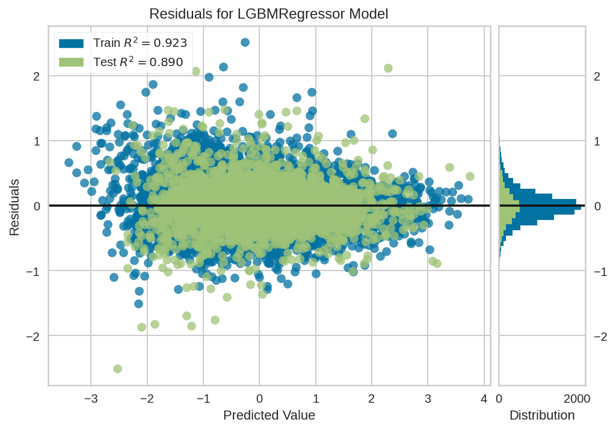

```python
# AUC-ROC plot
pyc.plot_model(lgb, plot = 'residuals')
```

```python
# pyc.plot_model(lgb, plot = 'parameter')
```

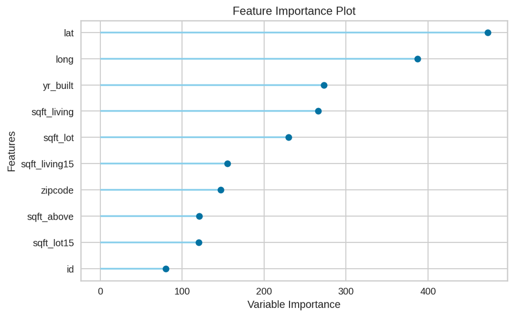

```python
pyc.plot_model(lgb, plot='feature')
```

```python
# evaluate model
# catboost is not available
pyc.evaluate_model(lgb)
```

# Ensemble Modelling

- [A Comprehensive Guide to Ensemble Learning](https://www.analyticsvidhya.com/blog/2018/06/comprehensive-guide-for-ensemble-models/?utm_source=blog&utm_medium=pycaret-machine-learning-model-seconds).

```
ensemble_model(estimator, method='Bagging', fold=10, n_estimators=10, round=4, verbose=True)

method: 'Bagging' or 'Boosting', default = 'Bagging'
```

```python
# pyc.ensemble_model?
```

```python
dt = pyc.create_model('dt')
```

|  | MAE | MSE | RMSE | R2 | RMSLE | MAPE |
| --- | --- | --- | --- | --- | --- | --- |
| 0 | 105087.1521 | 3.879945e+10 | 196975.7545 | 0.7409 | 0.2605 | 0.1949 |
| 1 | 106371.4429 | 3.908185e+10 | 197691.3069 | 0.7323 | 0.2594 | 0.1886 |
| 2 | 112297.3970 | 5.007604e+10 | 223776.7740 | 0.6785 | 0.2653 | 0.1964 |
| 3 | 100977.1602 | 3.842983e+10 | 196035.2812 | 0.7073 | 0.2499 | 0.1843 |
| 4 | 107969.2799 | 4.279011e+10 | 206857.7128 | 0.6696 | 0.2717 | 0.1963 |
| 5 | 103326.1514 | 3.280744e+10 | 181128.2536 | 0.6860 | 0.2658 | 0.1945 |
| 6 | 109090.0738 | 3.727536e+10 | 193068.2729 | 0.6856 | 0.2749 | 0.2056 |
| 7 | 113866.2724 | 4.254017e+10 | 206252.6807 | 0.7026 | 0.2668 | 0.1975 |
| 8 | 106924.0672 | 4.184682e+10 | 204564.9625 | 0.6431 | 0.2624 | 0.1927 |
| 9 | 98262.3481 | 3.310170e+10 | 181938.7149 | 0.6911 | 0.2611 | 0.1893 |
| Mean | 106417.1345 | 3.967488e+10 | 198828.9714 | 0.6937 | 0.2638 | 0.1940 |
| SD | 4552.9865 | 4.791769e+09 | 11912.9418 | 0.0274 | 0.0066 | 0.0055 |

## Bagging

```python
dt_bagged = pyc.ensemble_model(dt, n_estimators=50,method='Bagging')
```

|  | MAE | MSE | RMSE | R2 | RMSLE | MAPE |
| --- | --- | --- | --- | --- | --- | --- |
| 0 | 73742.1944 | 2.075128e+10 | 144053.0465 | 0.8615 | 0.1873 | 0.1356 |
| 1 | 77846.5950 | 2.269144e+10 | 150636.7914 | 0.8446 | 0.1900 | 0.1340 |
| 2 | 76008.9750 | 2.663546e+10 | 163203.7268 | 0.8290 | 0.1752 | 0.1256 |
| 3 | 72161.3691 | 2.121861e+10 | 145666.1037 | 0.8384 | 0.1850 | 0.1310 |
| 4 | 75454.4990 | 2.141405e+10 | 146335.3883 | 0.8347 | 0.1859 | 0.1334 |
| 5 | 70841.1055 | 1.525008e+10 | 123491.2076 | 0.8541 | 0.1906 | 0.1371 |
| 6 | 74280.1768 | 1.808723e+10 | 134488.7570 | 0.8474 | 0.1937 | 0.1389 |
| 7 | 75619.3137 | 1.900825e+10 | 137870.4195 | 0.8671 | 0.1861 | 0.1308 |
| 8 | 71494.9830 | 1.912422e+10 | 138290.3423 | 0.8369 | 0.1820 | 0.1302 |
| 9 | 70246.7668 | 1.798092e+10 | 134092.9485 | 0.8322 | 0.1859 | 0.1326 |
| Mean | 73769.5978 | 2.021615e+10 | 141812.8732 | 0.8446 | 0.1862 | 0.1329 |
| SD | 2385.4806 | 2.947925e+09 | 10259.7445 | 0.0122 | 0.0048 | 0.0036 |

```python
# dt_bagged_tuned = pyc.tune_model('dt', ensemble=True,
#                       method='Bagging',fold=3, n_iter=10, optimize='R2')
```

## Boosting

```python
# dt_boosted_tuned = pyc.tune_model('dt', ensemble=True, method='Boosting')
```

## Blending

```
blend_models(estimator_list='All', fold=10, round=4, method='hard', turbo=True, verbose=True)
```

```python
# pyc.blend_models?
```

```python
# blend_soft = pyc.blend_models(estimator_list = [dt, lgb,cb], method = 'soft')
```

```python
# blend_hard = pyc.blend_models(estimator_list = [dt, lgb,cb], method = 'hard')
```

## Stacking

Stacking is another popular technique for ensembling but is less commonly implemented due to practical difficulties. Stacking is an ensemble learning technique that combines multiple models via a meta-model. Another way to think about stacking is that multiple models are trained to predict the outcome and a meta-model is created that uses the predictions from those models as an input along with the original features.

Selecting which method and models to use in stacking depends on the statistical properties of the dataset. Experimenting with different models and methods is the best way to find out which configuration will work best. However as a general rule of thumb, the models with strong yet diverse performance tend to improve results when used in stacking. One way to measure diversity is the correlation of predictions between models. You can analyze this using the plot parameter.

```
stack_models(estimator_list, meta_model=None, fold=10, round=4, method='soft', restack=True, plot=False, finalize=False, verbose=True)
```

```python
# pyc.stack_models?
```

```python
# stack_soft = pyc.stack_models(estimator_list = [dt, lgb,cb], method = 'soft')

# stack_soft2 = pyc.stack_models(estimator_list = [cb, lgb],
#                                           method = 'soft',
#                                          meta_model='dt')
```

```python
# stack_hard = pyc.stack_models(estimator_list = [dt, lgb,cb], method = 'hard')
```

```python
# stack_soft_plot = pyc.stack_models([dt,cb,lgb], plot=True)
```

# Model Interpretation

```python
df_eval
```

|  | Model | Description | MAE | MSE | RMSE | R2 | RMSLE | MAPE |
| --- | --- | --- | --- | --- | --- | --- | --- | --- |
| 0 | cb | tuned, n_iter=10 | 63561.3715 | 1.424778e+10 | 119320.2978 | 0.8895 | 0.1651 | 0.1186 |
| 1 | catboost | default | 64436.3106 | 1.432340e+10 | 119254.9145 | 0.8890 | 0.1661 | 0.1201 |
| 2 | lda | default | 66869.0314 | 1.562930e+10 | 124447.5552 | 0.8793 | 0.1703 | 0.1236 |

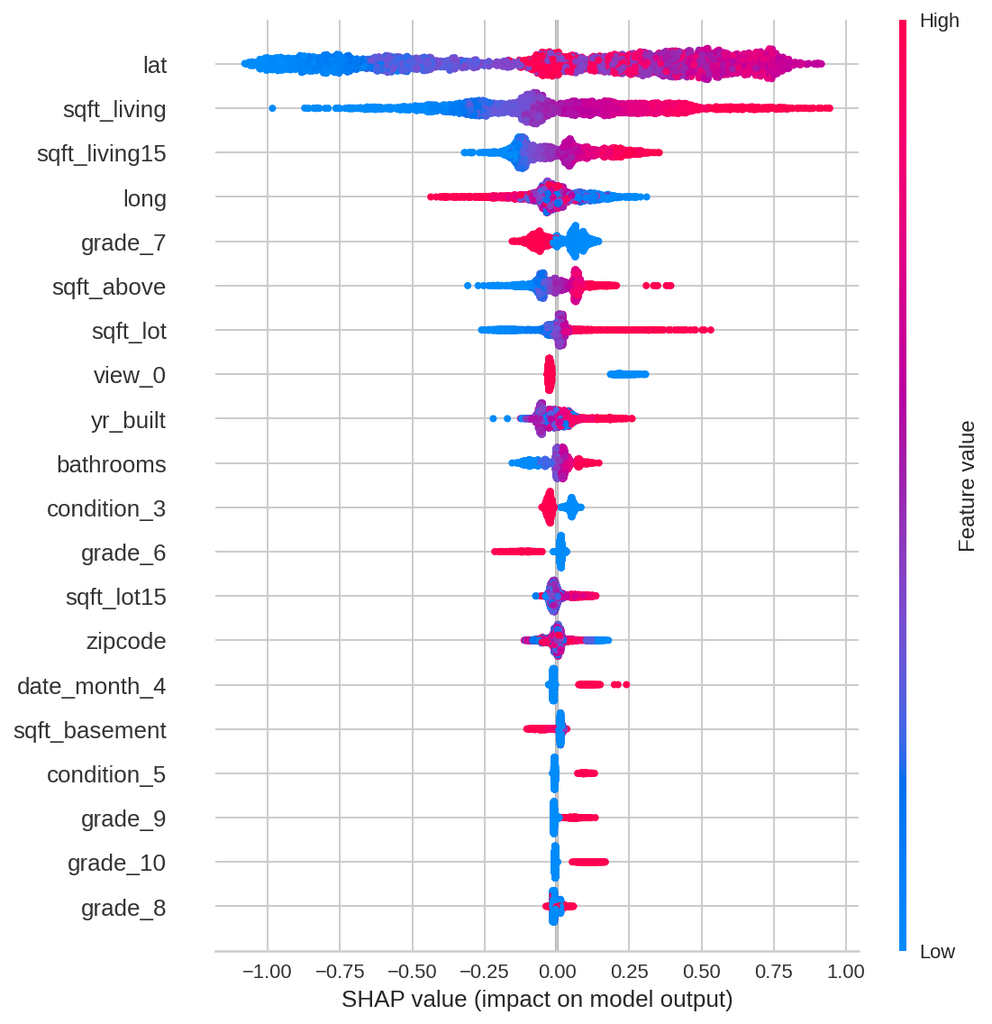

```python
# interpret_model: SHAP
pyc.interpret_model(cb)
```

[figure not shown]

```python
# interpret model : Correlation
pyc.interpret_model(xgb,plot='correlation')
```